# Chapter 7 Coding Set

**Remember to save a copy of this template BEFORE YOU START WORKING :)**

Work completed by [Isaiah Garrison].

If you start to struggle with a problem for an extended period of time, remember you can go comment on two other submissions now (seeing other student work helps), or you can post in our discussion forum for questions, which can also earn you extra credit.

## Imports

**If your program requires additional modules, external resources, or files, use this cell to set them up**

```python
# configure your environment

# you can uncomment this code to make use of files stored in your Google Drive
# from google.colab import drive
# drive.mount('/content/drive')

# you can uncomment the following line of code to use the pandas library
# import pandas as pd
```

## Algorithm Workbench

### Problem 2

#### Question Text

Assume names references a list. Write a loop that displays each element of the list.

#### High-Level Overview

So first I had to make the list of course. I reference the chapter for syntax as always. I remembered when starting to make the loop that you can use len and attach the sloop variable to the present variable to make it reference it. I actually did forget to use quotation marks but quickly fixed it.

```python
# add your code to this cell
# remember to include comments like this one for most of your code
# remember to "Run cell" once you're done, excecuting your code so the output is displayed below

# Creating the list
names = ["ethan", "zoe", "mia", "jack"]

# Displaying each name in a loop
for i in range(len(names)):
    print(names[i])
```

```
ethan
zoe
mia
jack
```

### Problem 5

#### Question Text

Write a function that accepts a list as an argument (assume the list contains integers) and returns the total of the values in the list.

#### High-Level Overview

My general first approach was similar to the last one. I started off with the list then got onto the function. I knew you had to add the variable into the fuction argument for it to take any list and remembered how to calculate the total from past assignments. Overall, not bad.

```python
# add your code to this cell
# remember to include comments like this one for most of your code
# remember to "Run cell" once you're done, excecuting your code so the output is displayed below

# Making the list
numbers = [1, 2, 3, 4, 5, 7]

# making the fuction
def total_calculator(list):
    total = 0
    for i in range(len(list)):
        total += numbers[i]
    return total

# Calling the function
print(total_calculator(numbers))
```

```
22
```

## Programming Exercises

### Problem 1

#### Question Text

Design a program that asks the user to enter a store’s sales for each day of the week. The amounts should be stored in a list. Use a loop to calculate the total sales for the week and display the result.

#### High-Level Overview

This one is pretty simple. I also realized that I should be making functions to reduce global variables so I am gonna start doing that. I first asked for the sales for the week. I then made the list and loop to calculate total just like the previous question.

```python
# add your code to this cell
# remember to include comments like this one for most of your code
# remember to "Run cell" once you're done, excecuting your code so the output is displayed below

def main():
    # Ask user for sales during the week
    monday_sales = float(input("Please enter the store's sales for Monday:  "))
    tuesday_sales = float(input("Please enter the store's sales for Tuesday:  "))
    wednesday_sales = float(input("Please enter the store's sales for Wednesday:  "))
    thursday_sales = float(input("Please enter the store's sales for Thursday:  "))
    friday_sales = float(input("Please enter the store's sales for Friday:  "))
    saturday_sales = float(input("Please enter the store's sales for Saturday:  "))
    sunday_sales = float(input("Please enter the store's sales for Sunday:  "))
    # Creating the list
    weekly_sales = [monday_sales, tuesday_sales, wednesday_sales, thursday_sales, friday_sales, saturday_sales, sunday_sales]
    # Setting the value for total
    total = 0
    for i in range(len(weekly_sales)):
        total += weekly_sales[i]
    return total

print(f"The total sales for the week is {main()}")
```

```
The total sales for the week is 95.0
```

### Problem 14

#### Question Text

Create a text file that contains your expenses for last month in the following categories:  
Rent Gas Food Clothing Car payment Misc

#### High-Level Overview

This one was of course a bit buggy. I had to figure out how to import the file from my drive and make sure everything was saved properly. I didn't have any problems making the pie chart, only forgot to add the .pyplot at the end. Everything else was simple and just using the same syntax as the example.

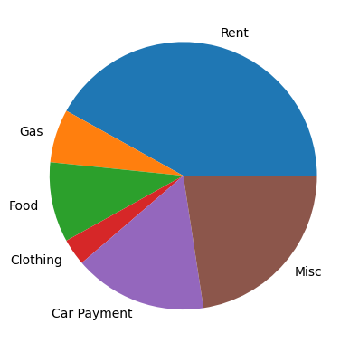

```python
# add your code to this cell
# remember to include comments like this one for most of your code
# remember to "Run cell" once you're done, excecuting your code so the output is displayed below

# importing the pie chart package
import matplotlib.pyplot as plt

# Creating the fuction
def main():
    # Reading the bills file
    with open(r"C:\Users\igarr\OneDrive\Documents\GitHub\monthly_bills.txt") as import_file:
        expenses = import_file.readlines()
        # Removing the \n
        for i in range(len(expenses)):
            expenses[i] = float(expenses[i].rstrip())
        # creating pie chart
        slice_labels = ["Rent", "Gas", "Food", "Clothing", "Car Payment", "Misc"]
        plt.pie(expenses, labels=slice_labels)
        plt.show()

# Calling function
main()
```

### Problem 7

#### Question Text

The local driver’s license office has asked you to create an application that grades the written portion of the driver’s license exam. The exam has 20 multiple-choice questions. Here are the correct answers:

1. A
2. C
3. A
4. A
5. D
6. B
7. C
8. A
9. C
10. B
11. A
12. D
13. C
14. A
15. D
16. C
17. B
18. B
19. D
20. A

Your program should store these correct answers in a list. The program should read the student’s answers for each of the 20 questions from a text file and store the answers in another list. (Create your own text file to test the application.) After the student’s answers have been read from the file, the program should display a message indicating whether the student passed or failed the exam. (A student must correctly answer 15 of the 20 questions to pass the exam.) It should then display the total number of correctly answered questions, the total number of incorrectly answered questions, and a list showing the question numbers of the incorrectly answered questions.

#### High-Level Overview

This one took the longest by far. I had to think through each part of the question and figure out what to do for it specifically. Basically, I just broke down each step but in the end, I was able to piece it all together. I still kept forgetting small things like commas but easily fixed them after. I remembered some useful methods like append too.

```python
# add your code to this cell
# remember to include comments like this one for most of your code
# remember to "Run cell" once you're done, excecuting your code so the output is displayed below

def main():
    correct_answers = ["A", "C", "A", "A", "D", "B", "C", "A", "C", "B", "A", "D", "C", "A", "D", "C", "B", "B", "D", "A"]
    # Creating the student list
    with open(r"C:\Users\igarr\OneDrive\Documents\GitHub\student_answers.txt") as import_file:
        student_answers = import_file.readlines()
        # removing the new line marks
        for i in range(len(student_answers)):
            student_answers[i] = (student_answers[i].rstrip())
    # Setting the counts and list
    correct_count = 0
    incorrect_count = 0
    incorrect_list = []
    # Conting correct answers
    for i in range(len(correct_answers)):
        if correct_answers[i] == student_answers[i]:
            correct_count += 1
    # counting incorrect answers
    for i in range(len(correct_answers)):
        if correct_answers[i] != student_answers[i]:
            incorrect_count += 1
            incorrect_list.append(i + 1)
    # Displaying to user if passed or failed
    if correct_count >= 15:
        print("Congradulations, you have passed!")
    else:
        print("Sorry, you have failed the exam.")
    # displaying correct and incorrect count
    print(f"You have answered {correct_count} questions correctly, but have answered {incorrect_count} questions incorrectly")
    # displaying what questions the user got wrong
    print(f"Here are the questions that you got wrong:  {incorrect_list}")

# Running the fuction
if __name__ == "__main__":
    main()
```

```
Congradulations, you have passed!
You have answered 17 questions correctly, but have answered 3 questions incorrectly
Here are the questions that you got wrong:  [4, 9, 16]
```

### Problem 13

#### Question Text

Write a program that simulates a Magic 8 Ball, which is a fortune-telling toy that displays a random response to a yes or no question. In the student sample programs for this book, you will find a text file named 8_ball_responses.txt. The file contains 12 responses, such as “I don’t think so”, “Yes, of course!”, “I’m not sure”, and so forth. The program should read the responses from the file into a list. It should prompt the user to ask a question, then display one of the responses, randomly selected from the list. The program should repeat until the user is ready to quit.

Contents of 8_ball_responses.txt:

Yes, of course! Without a doubt, yes. You can count on it. For sure! Ask me later. I'm not sure. I can't tell you right now. I'll tell you after my nap. No way! I don't think so. Without a doubt, no. The answer is clearly NO.

#### High-Level Overview

This one only had one weird step and the rest was pretty simple. I only had to figure out how to import a module to execute a random variable from a list. After that, I simply used knowledge fromn previous works to write out the rest of the code. Overall, much easier

```python
# add your code to this cell
# remember to include comments like this one for most of your code
# remember to "Run cell" once you're done, excecuting your code so the output is displayed below

# importing random module
import random

# defining my main function
def main():
    # Creating the 8 ball list
    with open(r"C:\Users\igarr\OneDrive\Documents\GitHub\8_ball_responses.txt") as import_file:
        responses = import_file.readlines()
    # removing \n
    for i in range(len(responses)):
        responses[i] = (responses[i].rstrip())
    # setting up the 8 ball loop
    continuation = "yes"
    while continuation == "yes":
        input("Please ask your question:  ")
        # Grabbing the reandom response from list
        random_response = random.choice(responses)
        # Giving the response and seeing if they
        print(random_response)
        continuation = input("Would you like to ask another question? Please type yes or no:  ")

# Running the function
if __name__ == "__main__":
    main()
```

```
Ask me later.
```

```
I'm not sure.
```

## Helpful Checks

1. Did you comment every line of code with meaningful information that will help others reading your code?
2. Did you use appropriate names for your variables, functions, and/or classes?
3. Did you include a high-level explanation for each solution?
4. Did you run each cell that includes a final solution so the output is saved and easily viewed by others?
5. Are you sharing an editable link (i.e., Share > Anyone with the link > Editor) if using Colaboratory, or did you make more than ten commits if using GitHub?
6. Did you remember to comment on the submissions of two other students?